# Assignment GAM Fits for Hirsutism Data

Joan Oliveras Torra, Odysseas Kyparissis, Louis Tichelman

2024-07-09

# Preprocessing and Exploratory Data Analysis (EDA)

```r
library(mgcv)

# Load  data
hirsutism_data <- read.table('hirsutism.dat', header = T, sep = "\t")
```

## Treatment of Erroneous Data

Here we remove erroneous data, since there are values in the dataset with $FGm12$ value less than 0.

```r
i <- which(hirsutism_data$FGm12 < 0)
print(hirsutism_data[i,])
```

```
##    Treatment   FGm0     FGm3     FGm6     FGm12 SysPres DiaPres weight height
## 84         3 16.321 6.402696 4.292472 -1.163174     120      60     52   1.66
```

```r
hirsutism_data <- hirsutism_data[-i,]
```

## Treatment of Missing values

In this point, missing values check is performed.

```r
apply(is.na(hirsutism_data), 2, sum)
```

```
## Treatment      FGm0      FGm3      FGm6     FGm12   SysPres   DiaPres    weight
##         0         0         0         0         0         8         8         8
##    height
##         8
```

Although, in a real case scenario the rows containing the $8$ missing values for the variables: `SysPres`, `DiaPres`, `weight`, `height` should be imputed, here, for simplicity we decide to just drop those observations from the dataset, since imputation is not the primary goal of the assignment.

```r
hirsutism_data <- na.omit(hirsutism_data)
dim(hirsutism_data)
```

```
## [1] 90  9
```

## EDA

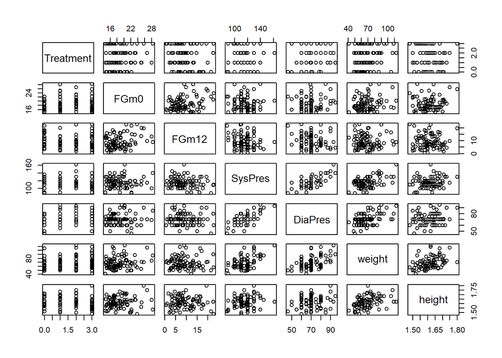

```r
plot(hirsutism_data[, -c(3:4)])
```

The presence of a nonlinear relationship is evident in the majority of variable associations with $FGm12$.

We can also check the distribution of the different variables:

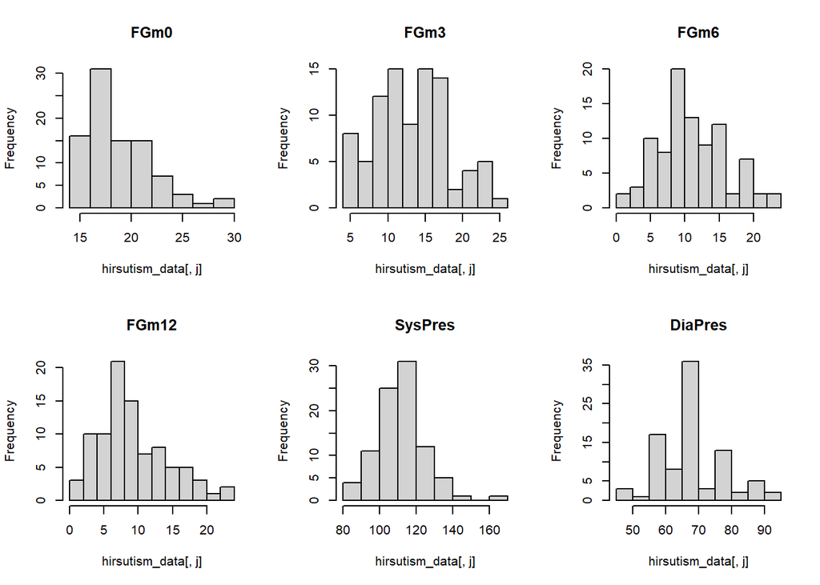

```r
par(mfrow=c(2,3))
for (j in 2:7) hist(hirsutism_data[,j],main=names(hirsutism_data)[j])
```

```r
apply(hirsutism_data[,-c(1,3,4)],2,sd)
```

```
##        FGm0       FGm12     SysPres     DiaPres      weight      height
##  3.12785250  5.14025888 13.05725890  9.58921575 14.71043795  0.06243738
```

```r
apply(hirsutism_data[, -c(1,3,4)], 2, function(x){diff(range(x))})
```

```
##       FGm0      FGm12    SysPres    DiaPres     weight     height
## 13.7883505 22.1670822 74.0000000 49.0000000 72.0000000  0.3199999
```

The aim here is to assess the potential classification of variable groups. Based on the previous results we can categorize them into three groups based: (*FGm0, FGm12*) ,(*SysPres, DiaPres, weight*) and (*height*). This categorization becomes important if we intend to utilize tensor product splines, particularly when applied across variables from distinct groups.

Ultimately, the `Treatment` variable, which includes $4$ distinct values, is converted into a factor as mandated by the requirement.

```r
hirsutism_data$Treatment <- as.factor(hirsutism_data$Treatment)
```

# Modelling

```r
attach(hirsutism_data)
set.seed(666)
```

## Fitting Linear Model

```r
linear.model <- gam(FGm12 ~ Treatment + FGm0 + SysPres  + DiaPres   + weight + height)

summary(linear.model)
```

```
##
## Family: gaussian
## Link function: identity
##
## Formula:
## FGm12 ~ Treatment + FGm0 + SysPres + DiaPres + weight + height
##
## Parametric coefficients:
##             Estimate Std. Error t value Pr(>|t|)
## (Intercept) 15.39972   15.00703   1.026 0.307868
## Treatment1  -4.30753    1.47070  -2.929 0.004417 **
## Treatment2  -4.21498    1.48684  -2.835 0.005787 **
## Treatment3  -3.48854    1.46673  -2.378 0.019740 *
## FGm0         0.59112    0.16753   3.528 0.000692 ***
## SysPres     -0.06202    0.05240  -1.184 0.240048
## DiaPres      0.02049    0.07135   0.287 0.774712
## weight       0.01550    0.04471   0.347 0.729763
## height      -5.94325    9.21465  -0.645 0.520764
## ---
## Signif. codes:  0 '***' 0.001 '**' 0.01 '*' 0.05 '.' 0.1 ' ' 1
##
##
## R-sq.(adj) =  0.155   Deviance explained = 23.1%
## GCV = 24.815  Scale est. = 22.333    n = 90
```

Evidently, the explained deviance is notably minimal. As previously noted, achieving a better fit would necessitate the use of a `Generalized Additive Model` with splines.

## Fitting Several GAMs

```r
gam.0<-gam(FGm12 ~ s(FGm0) + s(SysPres) + s(DiaPres) + s(weight) + s(height) + Treatment)
summary(gam.0)
```

```
##
## Family: gaussian
## Link function: identity
##
## Formula:
## FGm12 ~ s(FGm0) + s(SysPres) + s(DiaPres) + s(weight) + s(height) +
##     Treatment
##
## Parametric coefficients:
##             Estimate Std. Error t value Pr(>|t|)
## (Intercept)  12.4690     0.9846  12.663  < 2e-16 ***
## Treatment1   -4.8616     1.4012  -3.470 0.000867 ***
## Treatment2   -4.4944     1.4150  -3.176 0.002165 **
## Treatment3   -3.8083     1.4030  -2.714 0.008233 **
## ---
## Signif. codes:  0 '***' 0.001 '**' 0.01 '*' 0.05 '.' 0.1 ' ' 1
##
## Approximate significance of smooth terms:
##              edf Ref.df     F p-value
## s(FGm0)    5.986  7.113 3.628  0.0021 **
## s(SysPres) 1.000  1.000 2.179  0.1441
## s(DiaPres) 1.886  2.375 1.109  0.4227
## s(weight)  1.007  1.013 0.641  0.4308
## s(height)  1.001  1.001 0.816  0.3696
## ---
## Signif. codes:  0 '***' 0.001 '**' 0.01 '*' 0.05 '.' 0.1 ' ' 1
##
## R-sq.(adj) =  0.267   Deviance explained = 38.1%
## GCV =   23.2  Scale est. = 19.365    n = 90
```

The total Deviance explained stands at $38.1%$ for `gam.0`, a metric similar to $R^2$ but applicable to variables with non-Gaussian responses. It’s evident that some variables exhibit a non-linear relationship with $FGm0$.

Variables such as `weight`, `SysPres` and `height`, possessing equivalent degrees of freedom set at $1$, indicate that a smoothing term is unnecessary. Additionally, `DiaPres`, `weight`, and `height` exhibit high p-values, suggesting their exclusion from the model.

```r
gam.0b <- gam(FGm12 ~ s(FGm0) + s(SysPres) + DiaPres + weight + height + Treatment)
summary(gam.0b)
```

```
##
## Family: gaussian
## Link function: identity
##
## Formula:
## FGm12 ~ s(FGm0) + s(SysPres) + DiaPres + weight + height + Treatment
##
## Parametric coefficients:
##             Estimate Std. Error t value Pr(>|t|)
## (Intercept) 21.39020   14.53598   1.472 0.145266
## DiaPres      0.03180    0.06856   0.464 0.644151
## weight       0.03472    0.04362   0.796 0.428609
## height      -8.37900    9.15565  -0.915 0.362988
## Treatment1  -4.90090    1.41926  -3.453 0.000908 ***
## Treatment2  -4.53706    1.43322  -3.166 0.002225 **
## Treatment3  -3.76435    1.41770  -2.655 0.009646 **
## ---
## Signif. codes:  0 '***' 0.001 '**' 0.01 '*' 0.05 '.' 0.1 ' ' 1
##
## Approximate significance of smooth terms:
##              edf Ref.df     F p-value
## s(FGm0)    5.578  6.697 3.613 0.00224 **
## s(SysPres) 1.241  1.445 0.890 0.29124
## ---
## Signif. codes:  0 '***' 0.001 '**' 0.01 '*' 0.05 '.' 0.1 ' ' 1
##
## R-sq.(adj) =  0.243   Deviance explained = 35.2%
## GCV = 23.628  Scale est. = 20        n = 90
```

Model `gam.0b`, characterized as semiparametric, closely resembles `gam.0` due to the linear nature of the smooth fit, although it performs a bit more poorly.

Retaining the two more significant variables based on p-values, we attempt to model $FGm12$ without a smoothing spline for `SysPres`. Given the potential impact of variable removal on the necessity for a smoothing term in `SysPres`, we conduct a corresponding test.

```r
gam.1 <- gam(FGm12 ~ s(FGm0) + SysPres + Treatment)
summary(gam.1)
```

```
##
## Family: gaussian
## Link function: identity
##
## Formula:
## FGm12 ~ s(FGm0) + SysPres + Treatment
##
## Parametric coefficients:
##             Estimate Std. Error t value Pr(>|t|)
## (Intercept) 16.75301    4.42129   3.789 0.000292 ***
## SysPres     -0.03874    0.03827  -1.012 0.314393
## Treatment1  -4.82745    1.40107  -3.446 0.000912 ***
## Treatment2  -4.28198    1.40404  -3.050 0.003109 **
## Treatment3  -3.27328    1.34342  -2.437 0.017060 *
## ---
## Signif. codes:  0 '***' 0.001 '**' 0.01 '*' 0.05 '.' 0.1 ' ' 1
##
## Approximate significance of smooth terms:
##           edf Ref.df     F p-value
## s(FGm0) 5.367  6.475 3.753 0.00216 **
## ---
## Signif. codes:  0 '***' 0.001 '**' 0.01 '*' 0.05 '.' 0.1 ' ' 1
##
## R-sq.(adj) =  0.249   Deviance explained = 32.8%
## GCV = 22.435  Scale est. = 19.851    n = 90
```

```r
gam.1b <- gam(FGm12 ~ s(FGm0) + s(SysPres) + Treatment)
summary(gam.1b)
```

```
##
## Family: gaussian
## Link function: identity
##
## Formula:
## FGm12 ~ s(FGm0) + s(SysPres) + Treatment
##
## Parametric coefficients:
##             Estimate Std. Error t value Pr(>|t|)
## (Intercept)  12.2855     0.9711  12.651  < 2e-16 ***
## Treatment1   -4.8968     1.3927  -3.516  0.00073 ***
## Treatment2   -4.2853     1.3965  -3.068  0.00295 **
## Treatment3   -3.2797     1.3350  -2.457  0.01622 *
## ---
## Signif. codes:  0 '***' 0.001 '**' 0.01 '*' 0.05 '.' 0.1 ' ' 1
##
## Approximate significance of smooth terms:
##              edf Ref.df     F p-value
## s(FGm0)    5.593  6.711 3.794 0.00177 **
## s(SysPres) 1.660  2.091 0.946 0.42068
## ---
## Signif. codes:  0 '***' 0.001 '**' 0.01 '*' 0.05 '.' 0.1 ' ' 1
##
## R-sq.(adj) =  0.261   Deviance explained = 34.6%
## GCV =  22.32  Scale est. = 19.529    n = 90
```

```r
anova(gam.0, gam.1, test="F")
```

```
## Analysis of Deviance Table
##
## Model 1: FGm12 ~ s(FGm0) + s(SysPres) + s(DiaPres) + s(weight) + s(height) +
##     Treatment
## Model 2: FGm12 ~ s(FGm0) + SysPres + Treatment
##   Resid. Df Resid. Dev      Df Deviance      F Pr(>F)
## 1    73.498     1454.7
## 2    78.525     1580.8 -5.0272  -126.11 1.2954 0.2751
```

```r
anova(gam.0, gam.1b, test="F")
```

```
## Analysis of Deviance Table
##
## Model 1: FGm12 ~ s(FGm0) + s(SysPres) + s(DiaPres) + s(weight) + s(height) +
##     Treatment
## Model 2: FGm12 ~ s(FGm0) + s(SysPres) + Treatment
##   Resid. Df Resid. Dev      Df Deviance      F Pr(>F)
## 1    73.498     1454.7
## 2    77.198     1537.9 -3.7006  -83.228 1.1614 0.3339
```

Considering the Deviance explained, both models exhibit a notably high p-value for the fit. Eliminating the smoothing term on `SysPres` does not contribute positively to predicting the response variable `FGm12`, as indicated by the p-values of $0.2751$ and $0.3339$. This outcome is reinforced by the anova test, where we fail to reject the null hypothesis, implying that the second/newer model is deemed correct.

Also, the deviance explained is significantly lower: $32.8%$ and $34.6%$ respectively.

To continue with, exploring a tensor product between variables from distinct groups can be intriguing. Recall that this is typically done when variables belong to two separate groups or possess different units.

### Tensor Products

We also examine the two types of tensor products:`te()` and `ti()`. The `te()` function generates a tensor product smooth, while `ti()` produces a tensor product interaction. Simply put, `ti()` does not assess the main effects, whereas `te()` does. Let’s begin by exploring `te()`.

```r
gam.te <- gam(FGm12 ~ s(FGm0) + te(SysPres, height) + Treatment)

gam.te1 <- gam(FGm12 ~ s(FGm0) + te(weight, height) + Treatment)

gam.te2 <- gam(FGm12 ~ s(FGm0) + te(DiaPres, height) + Treatment)

gam.te3 <- gam(FGm12 ~ s(FGm0) + te(SysPres, weight) + Treatment)

gam.te4 <- gam(FGm12 ~ s(FGm0) + te(DiaPres, weight) + Treatment)
```

```r
summary(gam.te)
```

```
##
## Family: gaussian
## Link function: identity
##
## Formula:
## FGm12 ~ s(FGm0) + te(SysPres, height) + Treatment
##
## Parametric coefficients:
##             Estimate Std. Error t value Pr(>|t|)
## (Intercept)  12.2034     0.9694  12.589  < 2e-16 ***
## Treatment1   -4.8429     1.3871  -3.491 0.000797 ***
## Treatment2   -3.8432     1.4088  -2.728 0.007881 **
## Treatment3   -3.4264     1.3560  -2.527 0.013552 *
## ---
## Signif. codes:  0 '***' 0.001 '**' 0.01 '*' 0.05 '.' 0.1 ' ' 1
##
## Approximate significance of smooth terms:
##                      edf Ref.df     F p-value
## s(FGm0)            5.455  6.556 3.428 0.00423 **
## te(SysPres,height) 3.199  3.374 1.438 0.23324
## ---
## Signif. codes:  0 '***' 0.001 '**' 0.01 '*' 0.05 '.' 0.1 ' ' 1
##
## R-sq.(adj) =  0.267   Deviance explained = 36.3%
## GCV = 22.547  Scale est. = 19.377    n = 90
```

```r
print("-----------------------------------")
```

```
## [1] "-----------------------------------"
```

```r
summary(gam.te1)
```

```
##
## Family: gaussian
## Link function: identity
##
## Formula:
## FGm12 ~ s(FGm0) + te(weight, height) + Treatment
##
## Parametric coefficients:
##             Estimate Std. Error t value Pr(>|t|)
## (Intercept)  12.6059     0.9834  12.818  < 2e-16 ***
## Treatment1   -5.1642     1.3879  -3.721 0.000377 ***
## Treatment2   -4.7288     1.4003  -3.377 0.001155 **
## Treatment3   -3.8295     1.4112  -2.714 0.008223 **
## ---
## Signif. codes:  0 '***' 0.001 '**' 0.01 '*' 0.05 '.' 0.1 ' ' 1
##
## Approximate significance of smooth terms:
##                     edf Ref.df     F  p-value
## s(FGm0)           5.980  7.083 4.221 0.000563 ***
## te(weight,height) 3.619  4.070 0.868 0.497329
## ---
## Signif. codes:  0 '***' 0.001 '**' 0.01 '*' 0.05 '.' 0.1 ' ' 1
##
## R-sq.(adj) =  0.267   Deviance explained = 37.1%
## GCV =  22.81  Scale est. = 19.363    n = 90
```

```r
print("-----------------------------------")
```

```
## [1] "-----------------------------------"
```

```r
summary(gam.te2)
```

```
##
## Family: gaussian
## Link function: identity
##
## Formula:
## FGm12 ~ s(FGm0) + te(DiaPres, height) + Treatment
##
## Parametric coefficients:
##             Estimate Std. Error t value Pr(>|t|)
## (Intercept)  12.2528     0.9834  12.460  < 2e-16 ***
## Treatment1   -4.8951     1.4082  -3.476 0.000852 ***
## Treatment2   -4.1167     1.4375  -2.864 0.005433 **
## Treatment3   -3.3131     1.3834  -2.395 0.019135 *
## ---
## Signif. codes:  0 '***' 0.001 '**' 0.01 '*' 0.05 '.' 0.1 ' ' 1
##
## Approximate significance of smooth terms:
##                      edf Ref.df     F p-value
## s(FGm0)            5.975  7.082 2.996 0.00719 **
## te(DiaPres,height) 5.411  6.910 0.633 0.72983
## ---
## Signif. codes:  0 '***' 0.001 '**' 0.01 '*' 0.05 '.' 0.1 ' ' 1
##
## R-sq.(adj) =  0.274   Deviance explained = 39.2%
## GCV = 23.123  Scale est. = 19.17     n = 90
```

```r
print("-----------------------------------")
```

```
## [1] "-----------------------------------"
```

```r
summary(gam.te3)
```

```
##
## Family: gaussian
## Link function: identity
##
## Formula:
## FGm12 ~ s(FGm0) + te(SysPres, weight) + Treatment
##
## Parametric coefficients:
##             Estimate Std. Error t value Pr(>|t|)
## (Intercept)  12.2289     0.9791  12.490  < 2e-16 ***
## Treatment1   -4.6517     1.3971  -3.330  0.00133 **
## Treatment2   -4.2233     1.4136  -2.987  0.00376 **
## Treatment3   -3.3490     1.3490  -2.483  0.01520 *
## ---
## Signif. codes:  0 '***' 0.001 '**' 0.01 '*' 0.05 '.' 0.1 ' ' 1
##
## Approximate significance of smooth terms:
##                      edf Ref.df     F p-value
## s(FGm0)            5.299  6.398 3.677 0.00227 **
## te(SysPres,weight) 3.000  3.000 1.300 0.28057
## ---
## Signif. codes:  0 '***' 0.001 '**' 0.01 '*' 0.05 '.' 0.1 ' ' 1
##
## R-sq.(adj) =  0.258   Deviance explained = 35.2%
## GCV = 22.715  Scale est. = 19.611    n = 90
```

```r
print("-----------------------------------")
```

```
## [1] "-----------------------------------"
```

```r
summary(gam.te4)
```

```
##
## Family: gaussian
## Link function: identity
##
## Formula:
## FGm12 ~ s(FGm0) + te(DiaPres, weight) + Treatment
##
## Parametric coefficients:
##             Estimate Std. Error t value Pr(>|t|)
## (Intercept)  12.4544     0.9795  12.715  < 2e-16 ***
## Treatment1   -5.1081     1.3972  -3.656 0.000465 ***
## Treatment2   -4.5366     1.4114  -3.214 0.001908 **
## Treatment3   -3.4887     1.3486  -2.587 0.011557 *
## ---
## Signif. codes:  0 '***' 0.001 '**' 0.01 '*' 0.05 '.' 0.1 ' ' 1
##
## Approximate significance of smooth terms:
##                      edf Ref.df     F p-value
## s(FGm0)            5.679  6.807 3.888 0.00116 **
## te(DiaPres,weight) 3.000  3.000 1.265 0.29224
## ---
## Signif. codes:  0 '***' 0.001 '**' 0.01 '*' 0.05 '.' 0.1 ' ' 1
##
## R-sq.(adj) =  0.263   Deviance explained =   36%
## GCV = 22.658  Scale est. = 19.466    n = 90
```

Below, all of the new models are compared with the original model.

```r
anova(gam.0, gam.te, test="F")
```

```
## Analysis of Deviance Table
##
## Model 1: FGm12 ~ s(FGm0) + s(SysPres) + s(DiaPres) + s(weight) + s(height) +
##     Treatment
## Model 2: FGm12 ~ s(FGm0) + te(SysPres, height) + Treatment
##   Resid. Df Resid. Dev      Df Deviance      F Pr(>F)
## 1    73.498     1454.7
## 2    76.070     1498.7 -2.5729  -44.077 0.8847 0.4398
```

```r
anova(gam.0, gam.te1, test="F")
```

```
## Analysis of Deviance Table
##
## Model 1: FGm12 ~ s(FGm0) + s(SysPres) + s(DiaPres) + s(weight) + s(height) +
##     Treatment
## Model 2: FGm12 ~ s(FGm0) + te(weight, height) + Treatment
##   Resid. Df Resid. Dev     Df Deviance      F Pr(>F)
## 1    73.498     1454.7
## 2    74.846     1479.4 -1.349  -24.692 0.9453 0.3609
```

```r
anova(gam.0, gam.te2, test="F")
```

```
## Analysis of Deviance Table
##
## Model 1: FGm12 ~ s(FGm0) + s(SysPres) + s(DiaPres) + s(weight) + s(height) +
##     Treatment
## Model 2: FGm12 ~ s(FGm0) + te(DiaPres, height) + Treatment
##   Resid. Df Resid. Dev     Df Deviance      F Pr(>F)
## 1    73.498     1454.7
## 2    72.009     1430.3 1.4888   24.348 0.8532 0.4006
```

```r
anova(gam.0, gam.te3, test="F")
```

```
## Analysis of Deviance Table
##
## Model 1: FGm12 ~ s(FGm0) + s(SysPres) + s(DiaPres) + s(weight) + s(height) +
##     Treatment
## Model 2: FGm12 ~ s(FGm0) + te(SysPres, weight) + Treatment
##   Resid. Df Resid. Dev      Df Deviance      F Pr(>F)
## 1    73.498     1454.7
## 2    76.602     1523.8 -3.1044  -69.147 1.1502 0.3354
```

```r
anova(gam.0, gam.te4, test="F")
```

```
## Analysis of Deviance Table
##
## Model 1: FGm12 ~ s(FGm0) + s(SysPres) + s(DiaPres) + s(weight) + s(height) +
##     Treatment
## Model 2: FGm12 ~ s(FGm0) + te(DiaPres, weight) + Treatment
##   Resid. Df Resid. Dev      Df Deviance      F Pr(>F)
## 1    73.498     1454.7
## 2    76.193     1505.1 -2.6956  -50.465 0.9668 0.4061
```

These combinations consistently yield unsatisfactory results in terms of Deviance explained and the significance of the `te()` terms. However, the Wald statistical test yields a high p-value, indicating that we cannot reject the null hypothesis, suggesting that the smoothing term is zero. Nevertheless, when we explore the summation of smoothing for two different pairs of tensor products , there is a notable improvement.

```r
gam.te5 <- gam(FGm12 ~ s(FGm0) + te(DiaPres,weight) + te(SysPres,height) + Treatment)
summary(gam.te5)
```

```
##
## Family: gaussian
## Link function: identity
##
## Formula:
## FGm12 ~ s(FGm0) + te(DiaPres, weight) + te(SysPres, height) +
##     Treatment
##
## Parametric coefficients:
##             Estimate Std. Error t value Pr(>|t|)
## (Intercept)  12.4264     0.9602  12.941  < 2e-16 ***
## Treatment1   -5.0275     1.3840  -3.633 0.000523 ***
## Treatment2   -4.0860     1.4017  -2.915 0.004739 **
## Treatment3   -3.8708     1.3873  -2.790 0.006742 **
## ---
## Signif. codes:  0 '***' 0.001 '**' 0.01 '*' 0.05 '.' 0.1 ' ' 1
##
## Approximate significance of smooth terms:
##                      edf Ref.df     F p-value
## s(FGm0)            5.738  6.813 3.050 0.00718 **
## te(DiaPres,weight) 3.000  3.000 1.588 0.19966
## te(SysPres,height) 5.352  6.239 1.323 0.28962
## ---
## Signif. codes:  0 '***' 0.001 '**' 0.01 '*' 0.05 '.' 0.1 ' ' 1
##
## R-sq.(adj) =  0.306   Deviance explained = 43.9%
## GCV = 22.945  Scale est. = 18.333    n = 90
```

```r
anova(gam.1b, gam.te5, test="F")
```

```
## Analysis of Deviance Table
##
## Model 1: FGm12 ~ s(FGm0) + s(SysPres) + Treatment
## Model 2: FGm12 ~ s(FGm0) + te(DiaPres, weight) + te(SysPres, height) +
##     Treatment
##   Resid. Df Resid. Dev     Df Deviance      F Pr(>F)
## 1    77.198     1537.9
## 2    69.948     1318.4 7.2501   219.54 1.6517  0.133
```

### Interactions with Categorical Data

Moving forward, the subsequent steps involves examining interactions between the categorical factor and the numerical variable. In `GAM`, this is accomplished using the `by` parameter within the `s()` function. The concept is that the smooth interacts with the factor `Treatment`, generating a distinct smooth for each factor level to capture inherent differences. We apply this approach to the top-performing models from the previous sections.

```r
gam.2 <- gam(FGm12 ~ s(FGm0, by=Treatment) + Treatment)
summary(gam.2)
```

```
##
## Family: gaussian
## Link function: identity
##
## Formula:
## FGm12 ~ s(FGm0, by = Treatment) + Treatment
##
## Parametric coefficients:
##             Estimate Std. Error t value Pr(>|t|)
## (Intercept)   15.056      2.980   5.053 2.95e-06 ***
## Treatment1    -7.504      3.127  -2.400   0.0189 *
## Treatment2    -7.084      3.130  -2.264   0.0265 *
## Treatment3    -5.771      3.121  -1.849   0.0683 .
## ---
## Signif. codes:  0 '***' 0.001 '**' 0.01 '*' 0.05 '.' 0.1 ' ' 1
##
## Approximate significance of smooth terms:
##                      edf Ref.df     F p-value
## s(FGm0):Treatment0 3.594  4.328 0.990 0.55751
## s(FGm0):Treatment1 1.954  2.462 2.730 0.06647 .
## s(FGm0):Treatment2 1.000  1.000 1.099 0.29786
## s(FGm0):Treatment3 4.054  4.972 3.847 0.00398 **
## ---
## Signif. codes:  0 '***' 0.001 '**' 0.01 '*' 0.05 '.' 0.1 ' ' 1
##
## R-sq.(adj) =  0.274   Deviance explained = 38.5%
## GCV = 22.899  Scale est. = 19.183    n = 90
```

```r
anova(gam.0,gam.2, test="F")
```

```
## Analysis of Deviance Table
##
## Model 1: FGm12 ~ s(FGm0) + s(SysPres) + s(DiaPres) + s(weight) + s(height) +
##     Treatment
## Model 2: FGm12 ~ s(FGm0, by = Treatment) + Treatment
##   Resid. Df Resid. Dev      Df Deviance     F Pr(>F)
## 1    73.498     1454.7
## 2    73.238     1446.4 0.25976   8.3016 1.666 0.1498
```

Upon examining the results of `anova()`, it appears that `gam.2` does not represent a significant improvement over `gam.0`. The p-value for the `F-test` is smaller compared to other scenarios. However, if we prioritize simplicity and scalability, `gam.2` outperforms `gam.0`.

```r
gam.2b <- gam(FGm12 ~ s(FGm0, by=Treatment) + te(DiaPres, weight)  +te(SysPres, height) + Treatment)
summary(gam.2b)
```

```
##
## Family: gaussian
## Link function: identity
##
## Formula:
## FGm12 ~ s(FGm0, by = Treatment) + te(DiaPres, weight) + te(SysPres,
##     height) + Treatment
##
## Parametric coefficients:
##             Estimate Std. Error t value Pr(>|t|)
## (Intercept)  11.1684     0.9761  11.442 5.91e-16 ***
## Treatment1   -3.5425     1.3809  -2.565   0.0132 *
## Treatment2   -1.8255     1.3339  -1.369   0.1769
## Treatment3   -2.6735     1.3796  -1.938   0.0580 .
## ---
## Signif. codes:  0 '***' 0.001 '**' 0.01 '*' 0.05 '.' 0.1 ' ' 1
##
## Approximate significance of smooth terms:
##                       edf Ref.df     F  p-value
## s(FGm0):Treatment0  1.000  1.000 0.013 0.911349
## s(FGm0):Treatment1  4.545  5.400 2.459 0.039098 *
## s(FGm0):Treatment2  1.000  1.000 0.222 0.639275
## s(FGm0):Treatment3  5.707  6.657 4.573 0.000744 ***
## te(DiaPres,weight) 11.736 13.150 2.112 0.027748 *
## te(SysPres,height)  8.866 10.713 1.892 0.070636 .
## ---
## Signif. codes:  0 '***' 0.001 '**' 0.01 '*' 0.05 '.' 0.1 ' ' 1
##
## R-sq.(adj) =  0.524   Deviance explained = 71.5%
## GCV = 21.321  Scale est. = 12.59     n = 90
```

```r
anova(gam.0,gam.2b, test="F")
```

```
## Analysis of Deviance Table
##
## Model 1: FGm12 ~ s(FGm0) + s(SysPres) + s(DiaPres) + s(weight) + s(height) +
##     Treatment
## Model 2: FGm12 ~ s(FGm0, by = Treatment) + te(DiaPres, weight) + te(SysPres,
##     height) + Treatment
##   Resid. Df Resid. Dev     Df Deviance      F   Pr(>F)
## 1    73.498    1454.67
## 2    48.079     669.11 25.418   785.55 2.4547 0.003612 **
## ---
## Signif. codes:  0 '***' 0.001 '**' 0.01 '*' 0.05 '.' 0.1 ' ' 1
```

On the other hand, `gam.2b` yields exceptional results, explaining the deviance at `71.5%`. The anova test rejects the null hypothesis, clearly indicating that `gam.2b` is a superior model to the initial one. This will serve as our final model.

It’s worth noting that there are numerous unexplored combinations, such as smoothing interactions between variables. This can be accomplished either linearly (e.g., weight * height) or by defining a tensor product using `ti()`. For instance, we might consider:

```r
gam.3 <- gam(FGm12 ~ s(FGm0, by=Treatment) + ti(DiaPres,weight) + ti(SysPres,height) + Treatment)
summary(gam.3)
```

```
##
## Family: gaussian
## Link function: identity
##
## Formula:
## FGm12 ~ s(FGm0, by = Treatment) + ti(DiaPres, weight) + ti(SysPres,
##     height) + Treatment
##
## Parametric coefficients:
##             Estimate Std. Error t value Pr(>|t|)
## (Intercept)   11.121      1.019  10.910 2.91e-16 ***
## Treatment1    -4.474      1.364  -3.279  0.00169 **
## Treatment2    -2.647      1.350  -1.961  0.05418 .
## Treatment3    -2.539      1.353  -1.876  0.06520 .
## ---
## Signif. codes:  0 '***' 0.001 '**' 0.01 '*' 0.05 '.' 0.1 ' ' 1
##
## Approximate significance of smooth terms:
##                      edf Ref.df     F p-value
## s(FGm0):Treatment0 1.000  1.000 0.044  0.8336
## s(FGm0):Treatment1 4.633  5.520 3.022  0.0130 *
## s(FGm0):Treatment2 1.000  1.000 0.163  0.6878
## s(FGm0):Treatment3 4.971  5.892 2.715  0.0218 *
## ti(DiaPres,weight) 4.496  5.674 1.603  0.1667
## ti(SysPres,height) 5.684  6.899 1.957  0.0977 .
## ---
## Signif. codes:  0 '***' 0.001 '**' 0.01 '*' 0.05 '.' 0.1 ' ' 1
##
## R-sq.(adj) =  0.436   Deviance explained = 59.3%
## GCV = 20.902  Scale est. = 14.914    n = 90
```

Model `gam.2b` remains the top-performing choice, with a deviance of `59.3%` for `gam.3`.

### Examination of Final Model

In examining our selected final model, we explore its features through `summary`, `plot`, `vis.gam`, and `gam.check`.

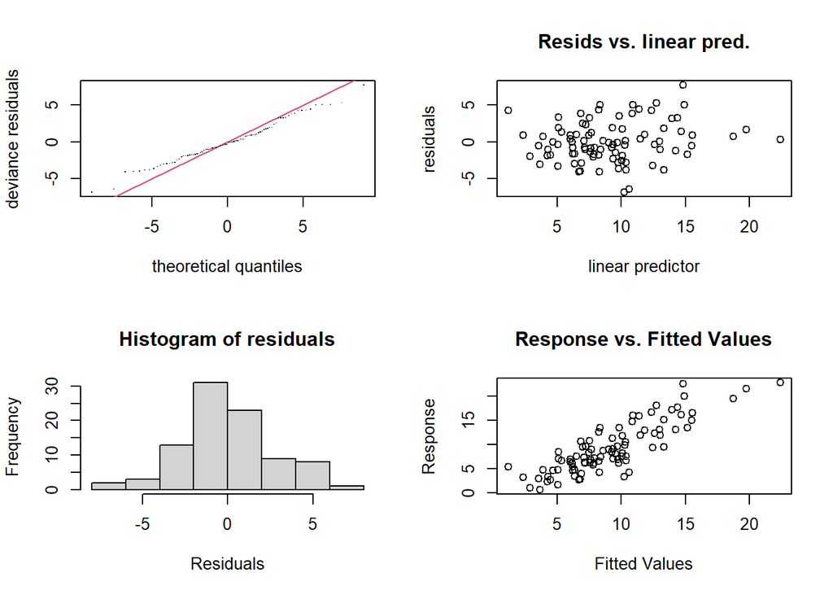

```
##
## Method: GCV   Optimizer: magic
## Smoothing parameter selection converged after 18 iterations.
## The RMS GCV score gradient at convergence was 4.723843e-07 .
## The Hessian was positive definite.
## Model rank =  88 / 88
##
## Basis dimension (k) checking results. Low p-value (k-index<1) may
## indicate that k is too low, especially if edf is close to k'.
##
##                       k'   edf k-index p-value
## s(FGm0):Treatment0  9.00  1.00    1.06   0.590
## s(FGm0):Treatment1  9.00  4.54    1.06   0.735
## s(FGm0):Treatment2  9.00  1.00    1.06   0.690
## s(FGm0):Treatment3  9.00  5.71    1.06   0.705
## te(DiaPres,weight) 24.00 11.74    1.09   0.800
## te(SysPres,height) 24.00  8.87    0.84   0.045 *
## ---
## Signif. codes:  0 '***' 0.001 '**' 0.01 '*' 0.05 '.' 0.1 ' ' 1
```

```r
par(mfrow=c(2,2))
gam.check(gam.2b)
```

The `gam.check` ensures that the chosen basis dimension is suitable for this model. Low p-values suggest that the chosen dimension, `k`, might be too low. However, this issue only arises for `te(SysPres, height)`. Nevertheless, as it happens solely to the threshold value, and the effective degrees of freedom (`edf`) are significantly different from `k`, no corrective action is required.

The residual plots depict the majority of residuals located around zero, and a somewhat linear trend is presented in the `response vs. fitted` plot.

The graphs below illustrates some of the bivariate relationships between `Fgm12` and pairs of variables.

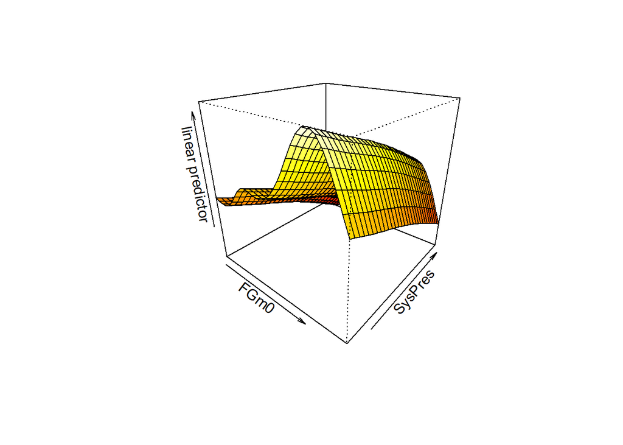

```r
vis.gam(gam.2b,view=c("FGm0","SysPres"),
        theta = 40, phi = 25, r = sqrt(3), d = 1)
```

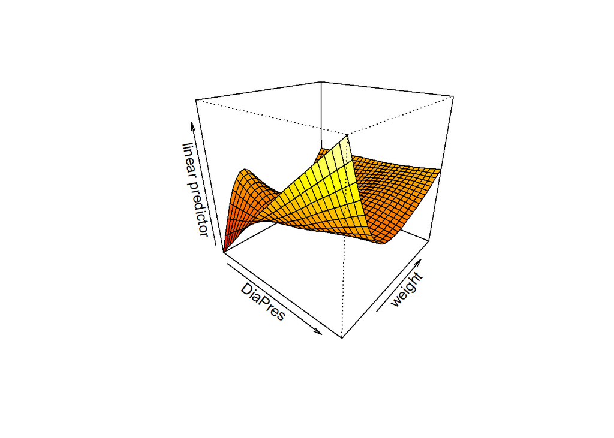

```r
vis.gam(gam.2b,view=c("DiaPres","weight"),
        theta = 40, phi = 25, r = sqrt(3), d = 1,)
```

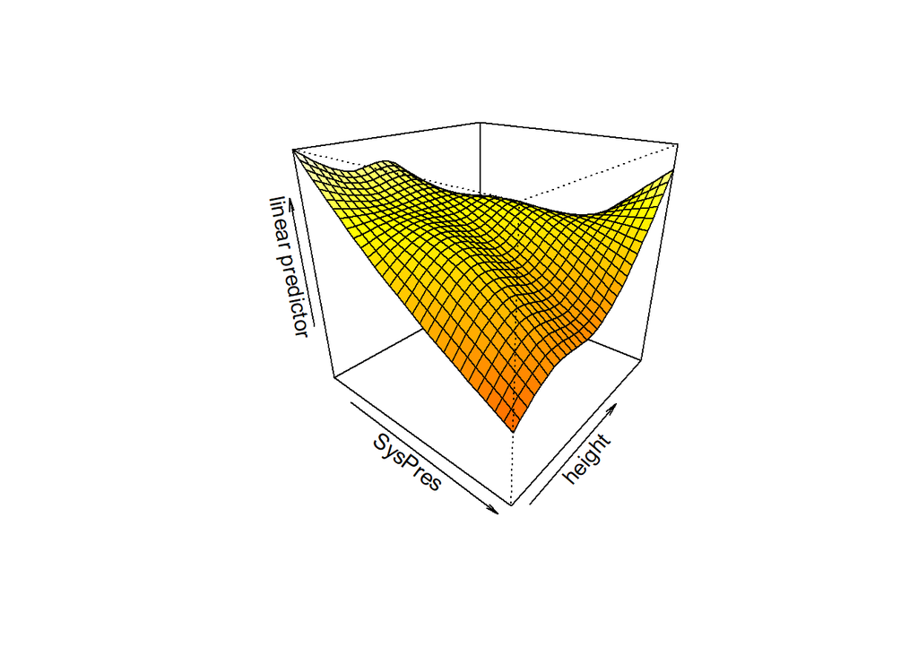

```r
vis.gam(gam.2b,view=c("SysPres","height"),
        theta = 40, phi = 25, r = sqrt(3), d = 1,)
```

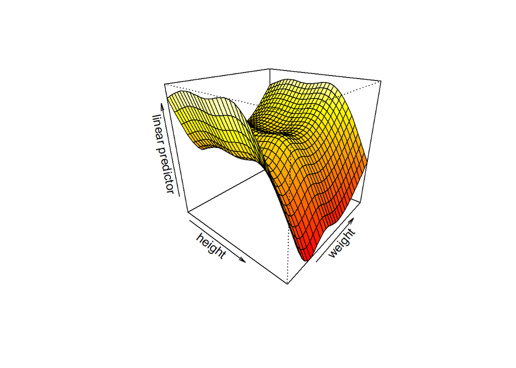

```r
vis.gam(gam.2b,view=c("height","weight"),
        theta = 40, phi = 25, r = sqrt(3), d = 1,)
```

Lastly, these plots illustrate the nonlinear response within the combination of `(FGm0, Treatment level)` and highlight the disparity in response when a tensor product spline is employed.

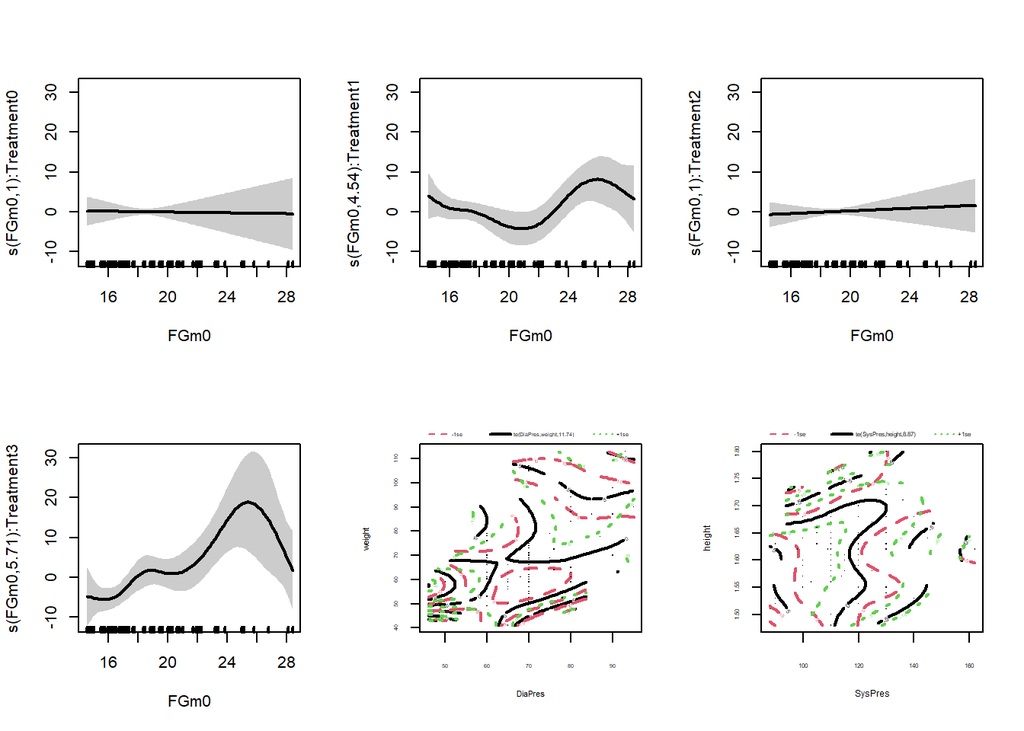

```r
plot(gam.2b, residuals = TRUE, shade=TRUE, seWithMean=TRUE, pages = 1, lwd=2)
```

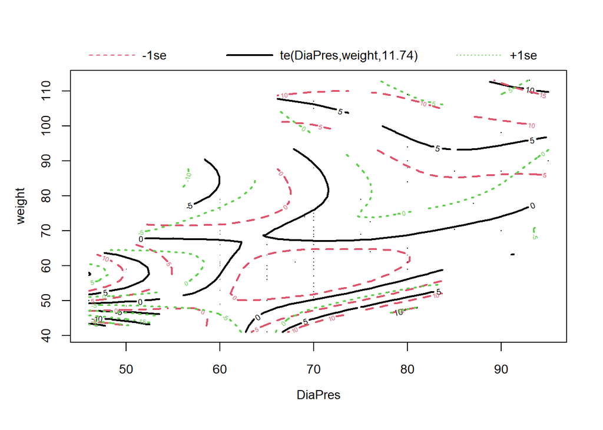

```r
par(mfrow=c(1,1))
plot(gam.2b, select = 5, residuals = TRUE, se=TRUE, lwd=2)
```

# Conclusion

Upon completing the fitting of all models, it becomes evident that the application of smoothing techniques in `Generalized Additive Models (GAM)` enhances the initial results compared to using just a `Generalized Linear Model (GLM)`. Without considering interactions or tensor products, the explained deviance appears to remain relatively low, hovering around $40%$. This is attributed to latent information within the nonlinear space generated by two or more variables. In essence, a better explanation of the response is achieved when considering a basis for the tensor product of these variables.

Additionally, favorable results are obtained when incorporating smoothed interactions between the factor and the `FGm0` variable. Notably, a tensor product interaction (`ti()`) yields satisfactory results, although it is evident that main effects are crucial, as `te()` provides the highest score.